# lambda_rates_simulation_clean

Original notebook was getting cluttered and over 1,000 lines long. I made this to clean up my workflow and remove some redundancies involved in working out and experimentation in the original.

```python
import math
import numpy as np
from scipy.stats import poisson, gamma as gamma_dist
import matplotlib.pyplot as plt
```

# a_is initialisation

```python
def ppoints(n, a=None):
    if a is None:
        a = 3/8 if n <= 10 else 1/2
    return (np.arange(1, n + 1) - a) / (n + 1 - 2*a)
```

a_is follow a power law (a_is prop. E^-2).

```python
E = ppoints(100) * 3 + 0.4
a_is = E**-2
a_is = 10 * a_is / a_is.sum()

print(E)
```

```
## [0.415 0.445 0.475 0.505 0.535 0.565 0.595 0.625 0.655 0.685 0.715 0.745
##  0.775 0.805 0.835 0.865 0.895 0.925 0.955 0.985 1.015 1.045 1.075 1.105
##  1.135 1.165 1.195 1.225 1.255 1.285 1.315 1.345 1.375 1.405 1.435 1.465
##  1.495 1.525 1.555 1.585 1.615 1.645 1.675 1.705 1.735 1.765 1.795 1.825
##  1.855 1.885 1.915 1.945 1.975 2.005 2.035 2.065 2.095 2.125 2.155 2.185
##  2.215 2.245 2.275 2.305 2.335 2.365 2.395 2.425 2.455 2.485 2.515 2.545
##  2.575 2.605 2.635 2.665 2.695 2.725 2.755 2.785 2.815 2.845 2.875 2.905
##  2.935 2.965 2.995 3.025 3.055 3.085 3.115 3.145 3.175 3.205 3.235 3.265
##  3.295 3.325 3.355 3.385]
```

```python
print(a_is)
```

```
## [0.79008291 0.68714571 0.60308932 0.53356349 0.47540232 0.42625743
##  0.38435712 0.34834439 0.31716573 0.28999314 0.26616857 0.24516378
##  0.22655072 0.2099796  0.19516229 0.18185977 0.16987239 0.15903232
##  0.1491977  0.14024791 0.13207991 0.12460523 0.11774756 0.11144082
##  0.10562753 0.10025753 0.09528687 0.0906769  0.08639357 0.08240672
##  0.0786896  0.07521843 0.07197198 0.06893126 0.06607924 0.06340064
##  0.06088166 0.05850988 0.05627404 0.05416395 0.05217036 0.05028484
##  0.04849972 0.046808   0.04520328 0.04367968 0.04223184 0.0408548
##  0.03954404 0.03829536 0.0371049  0.03596911 0.03488467 0.03384855
##  0.03285792 0.03191014 0.03100279 0.0301336  0.02930045 0.02850139
##  0.02773457 0.02699828 0.02629094 0.02561103 0.02495716 0.02432801
##  0.02372236 0.02313904 0.02257698 0.02203515 0.0215126  0.02100841
##  0.02052175 0.0200518  0.01959781 0.01915907 0.0187349  0.01832466
##  0.01792774 0.01754359 0.01717165 0.01681142 0.0164624  0.01612414
##  0.0157962  0.01547816 0.01516964 0.01487024 0.01457963 0.01429745
##  0.01402338 0.01375712 0.01349837 0.01324686 0.0130023  0.01276446
##  0.01253309 0.01230795 0.01208882 0.01187549]
```

# cash stats definition and calculation on samples

```python
def standard_cash(mle, N_is, a_is):
  total = 0.0

  for N_i, a_i in zip(N_is, a_is):
      total += mle * a_i

      if (mle * a_i) > 0:
        total -= N_i * math.log(mle * a_i)

  return float(2 * total)


def full_cash(mle, N_is, a_is):
  total = 0.0

  for N_i, a_i in zip(N_is, a_is):
    total += mle * a_i - N_i

    if (mle * a_i) > 0:
        total -= N_i * math.log(mle * a_i)

    if N_i > 0:
      total += N_i * math.log(N_i)

  return float(2 * total)


def condn_cash(N_is, a_is):
  a_plus = 10.0 # avoiding floating point errors
  N_plus = sum(N_is)
  total = 0.0

  for N_i, a_i in zip(N_is, a_is):
    total += N_i * math.log(a_i) - N_i * math.log(a_plus)

    if N_i > 0:
      total += math.log(N_i ** N_i)

    if (N_plus ** N_i) > 0:
      total -= math.log(N_plus ** N_i)

  return float((-2) * total)
```

We change this to investigate its effects on the fit. If your data comes from somewhere else, what happens then?

```python
lambda_star = 5.0
a_plus = 10.0 # !!! if you change this change the above normalisation as well
```

```python
def sample(a_is, lambda_star=lambda_star):
  return [np.random.poisson(lambda_star * a_i) for a_i in a_is]
```

```python
datasets = [sample(a_is) for _ in range(10000)]

def cash_stats(datasets):
  mles = [sum(d) / a_plus for d in datasets]

  cs_std = [standard_cash(m, d, a_is) for m, d in zip(mles, datasets)]
  cs_full = [full_cash(m, d, a_is) for m, d in zip(mles, datasets)]
  cs_condn = [condn_cash(d, a_is) for d in datasets]

  return mles, cs_std, cs_full, cs_condn # (mles, cash-stats) to allow for fluent use in graph plotting
```

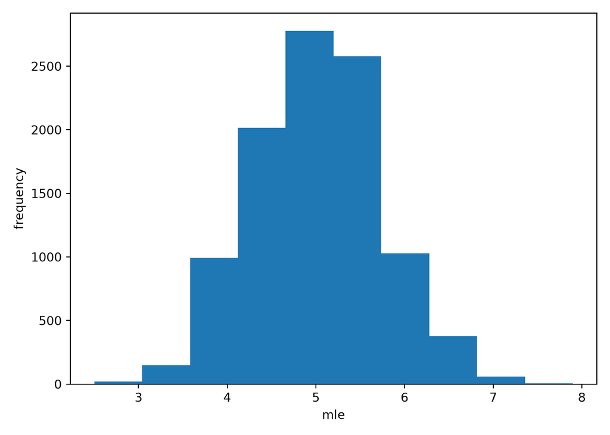

```python
mles = (cash_stats(datasets)[0])

plt.clf()
plt.hist(mles)
plt.ylabel("frequency")
plt.xlabel("mle")
plt.tight_layout()
plt.show()
```

Expect a bell curve that is more right-skewed the smaller the mle is on average.

```python
mles, cs_std, cs_full, cs_condn = cash_stats(datasets)
```

```python
def sim_plot(hyp, mles, cash_stat, inc_marginal, col):
  if hyp == 0:
    c_labels = {"standard": cs_std, "full": cs_full, "conditional": cs_condn}
  else:
    c_labels = {"standard": alt_cs_std, "full": alt_cs_full, "conditional": alt_cs_condn}
  c_chosen = c_labels[cash_stat]

  plt.clf()
  plt.scatter(mles, c_chosen, c=col, s=5, marker = '+')

  if inc_marginal:
    plt.scatter(x=np.zeros(len(c_chosen)), y=c_chosen, c=col, s=5, marker='+') # marginal dist'n

  plt.xlabel("mle")
  plt.ylabel(f"{cash_stat} cash statistic")
  plt.show()
```

# alt. hypothesis sampling

```python
def sample_alt(a_is):
  a_bar = lambda_star * np.average(a_is)
  return [np.random.poisson(a_bar) for _ in a_is] # ensure same sample size of 100

alt_datasets = [sample_alt(a_is) for _ in range(10000)]
alt_mles, alt_cs_std, alt_cs_full, alt_cs_condn = cash_stats(alt_datasets)
```